# Mini Project 01

2025-05-11

## TASK 1 - DATA EXPLORATION AND PREPARATION

```r
# 1.1)
setwd("N:/BSc(Hons) Mathematics-2025/STAT420 - Quantitative Data Analysis/Mini Projects/Project_01/ConnectZa_Customer_Retention")
rm(list = ls())
customer.data <- read.csv("connectza_churn_data.csv", row.names = 1)
str(customer.data)
```

```
## 'data.frame':    1000 obs. of  8 variables:
##  $ Age                    : int  54 31 42 46 43 37 56 37 62 37 ...
##  $ SubscriptionTier       : chr  "Premium" "Standard" "Basic" "Premium" ...
##  $ ContractDuration_Months: int  18 24 12 3 18 3 4 6 12 18 ...
##  $ DataUsage_GB           : num  52.6 13.3 0.3 5.4 5.2 5.8 0.7 12 2.1 18.8 ...
##  $ UsageFrequency         : num  19 8.6 6.5 22.4 3.8 4.5 6.5 6.3 4.6 10.4 ...
##  $ SupportTickets         : int  2 3 1 2 2 3 0 4 3 3 ...
##  $ SatisfactionScore      : int  7 7 8 6 8 7 7 6 6 7 ...
##  $ Churn                  : int  0 0 0 0 0 0 0 0 0 0 ...
```

CustomerID: This is just a unique identifier for each customer. It’s useful for tracking, but it won’t help with prediction, so we won’t include it in modelling. Churn: This is the main variable we’re trying to predict. A value of 1 means the customer left (churned), and 0 means they stayed. It’s a binary outcome. UsageFrequency: This tells us how often a customer uses the service each week. I think lower usage could be a sign that the customer isn’t very engaged, which might increase their chances of leaving. SupportTickets: This is the number of support queries raised in the last 3 months. A higher number here might suggest the customer is having problems, which could make them more likely to churn. Age: The age of the customer. This might influence how comfortable they are with tech or how likely they are to explore other providers. SubscriptionTier: This shows whether the customer is on a Basic, Standard, or Premium plan. I expect Premium users might be less likely to leave since they’re paying more and probably getting better service. SatisfactionScore: This is how satisfied customers said they were (on a scale of 1 to 10). It’s a direct measure of happiness with the service, so low scores here probably connect to a higher chance of churn. DataUsage_GB: This is how much data the customer uses per month. People who use more data might depend more on the service and be less likely to switch providers. ContractDuration_Months: This tells us how long their current contract is. I’d expect that customers with longer contracts are more “locked in” and therefore less likely to churn.

```r
#1.2)
#summary statistics for all variables(WITH VISUALISATION )
summary(customer.data)
```

```
##       Age        SubscriptionTier   ContractDuration_Months  DataUsage_GB
##  Min.   :18.00   Length:1000        Min.   : 1.00           Min.   :  0.0
##  1st Qu.:30.00   Class :character   1st Qu.: 6.00           1st Qu.:  2.1
##  Median :38.00   Mode  :character   Median :12.00           Median :  5.4
##  Mean   :37.97                      Mean   :15.25           Mean   : 10.4
##  3rd Qu.:46.00                      3rd Qu.:18.00           3rd Qu.: 12.1
##  Max.   :80.00                      Max.   :36.00           Max.   :185.8
##  UsageFrequency   SupportTickets   SatisfactionScore     Churn
##  Min.   : 1.000   Min.   : 0.000   Min.   : 2.000    Min.   :0.000
##  1st Qu.: 5.375   1st Qu.: 1.000   1st Qu.: 5.000    1st Qu.:0.000
##  Median : 8.000   Median : 2.000   Median : 6.000    Median :0.000
##  Mean   : 8.933   Mean   : 2.245   Mean   : 6.212    Mean   :0.134
##  3rd Qu.:11.425   3rd Qu.: 3.000   3rd Qu.: 7.000    3rd Qu.:0.000
##  Max.   :28.000   Max.   :10.000   Max.   :10.000    Max.   :1.000
```

```r
churn_rate <- mean(customer.data$Churn) * 100
churn_rate
```

```
## [1] 13.4
```

```r
cat("Overall churn rate:", round(churn_rate, 1), "%\n")
```

```
## Overall churn rate: 13.4 %
```

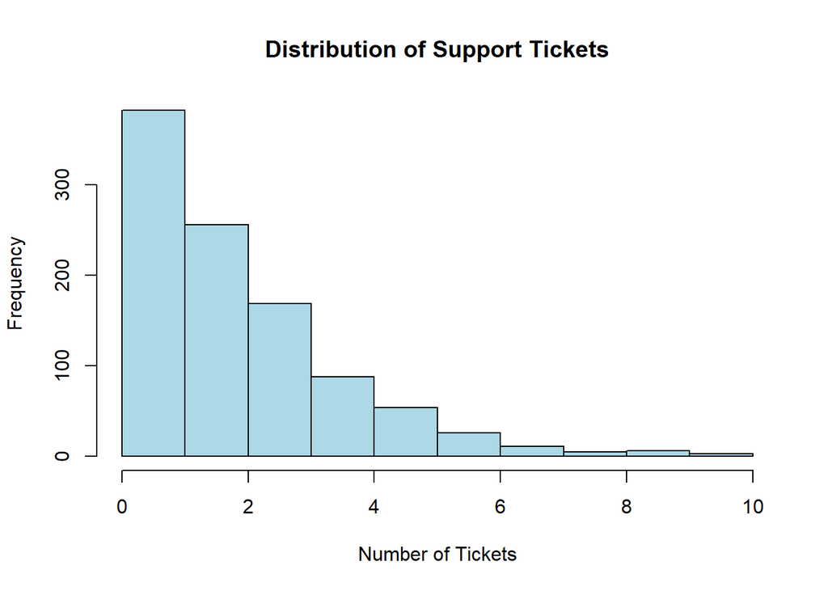

```r
# Distributions that are  skewed
hist(customer.data$SupportTickets,
     main = "Distribution of Support Tickets",
     xlab = "Number of Tickets",
     col = "lightblue")
```

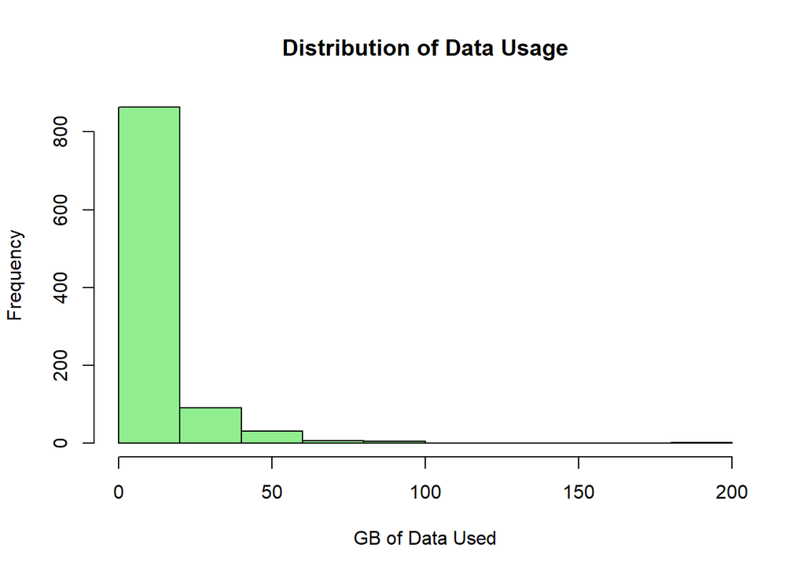

```r
hist(customer.data$DataUsage_GB,
     main = "Distribution of Data Usage",
     xlab = "GB of Data Used",
     col = "lightgreen")
```

The Skewed Variable are SupportTickets and DataUsage_GB with right-skew (Which we will use the Log Transformation)

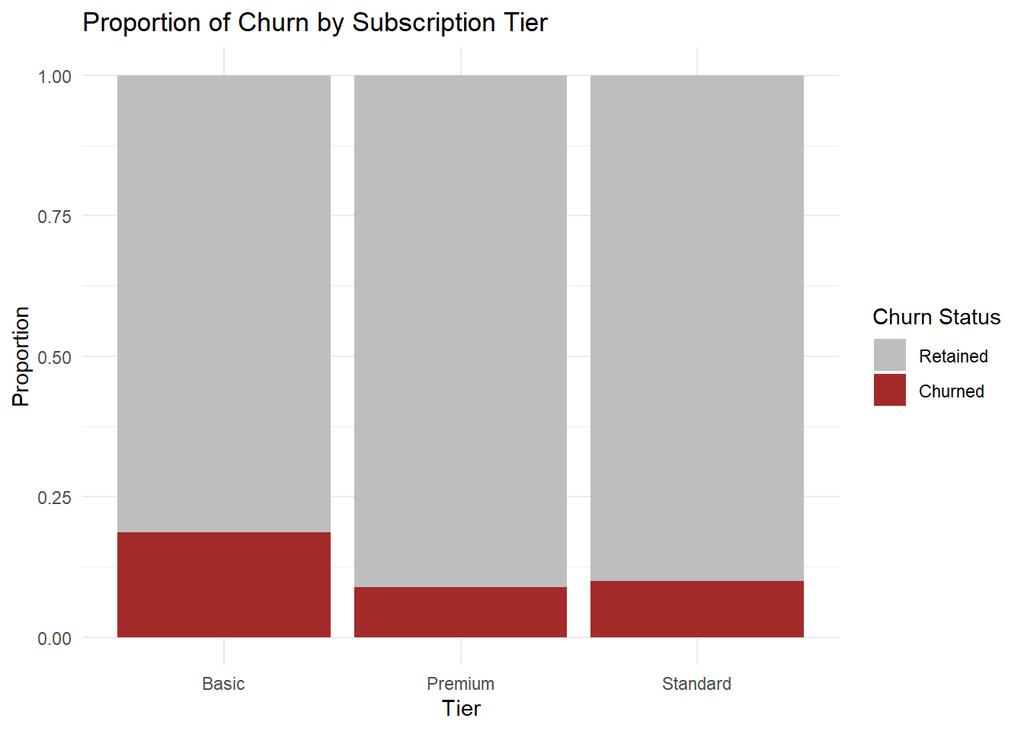

```r
#1.3
#Churn and SubscriptionTier
#a)
library(ggplot2)
ggplot(customer.data, aes(x = SubscriptionTier, fill = factor(Churn))) +
  geom_bar(position = "fill") +
  labs(
    title = "Proportion of Churn by Subscription Tier",
    x = "Tier",
    y = "Proportion",
    fill = "Churn Status"
  ) +
  scale_fill_manual(values = c("grey", "brown"), labels = c("Retained", "Churned")) +
  theme_minimal()
```

Basic tier likely shows higher churn. Premium customers often show lower churn due to better service value.

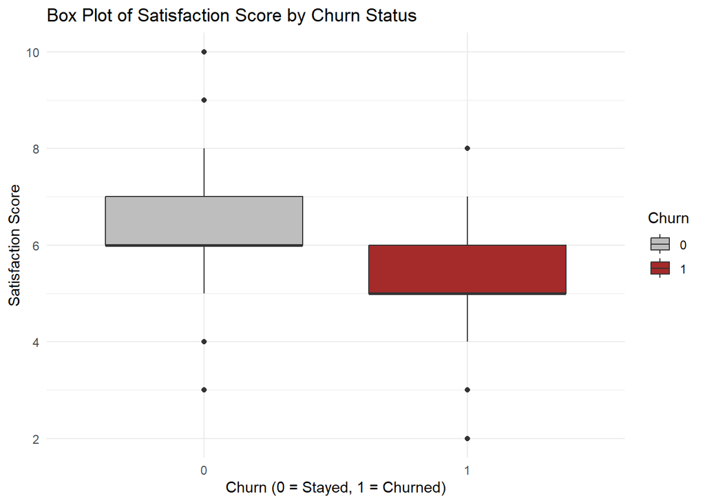

```r
#Churn vs SatisfactionScore
library(ggplot2)

ggplot(customer.data, aes(x = as.factor(Churn), y = SatisfactionScore, fill = as.factor(Churn))) +
  geom_boxplot() +
  labs(x = "Churn (0 = Stayed, 1 = Churned)",
       y = "Satisfaction Score",
       title = "Box Plot of Satisfaction Score by Churn Status",
       fill = "Churn") + scale_fill_manual(values = c("grey","brown"))+
  theme_minimal()
```

Sharp increase in churn for scores below 5. Indicates dissatisfaction as a key churn driver. This supports the idea that customer satisfaction is closely linked to churn. ConnectZA should focus on improving satisfaction especially among those scoring below 5 to help reduce churn.

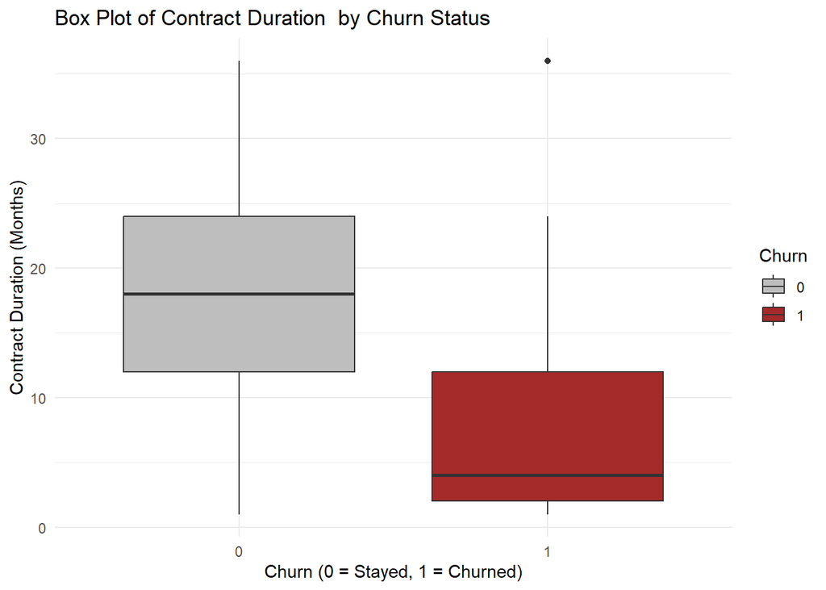

```r
#c)

ggplot(customer.data, aes(x = as.factor(Churn), y = ContractDuration_Months, fill = as.factor(Churn))) +
  geom_boxplot() +
  labs(x = "Churn (0 = Stayed, 1 = Churned)",
       y = "Contract Duration (Months)",
       title = "Box Plot of Contract Duration  by Churn Status",
       fill = "Churn") + scale_fill_manual(values = c("grey","brown"))+
  theme_minimal()
```

This box plot shows how long customers’ contracts are depending on whether they stayed or left. Churned customers (Churn = 1) usually have shorter contracts. The median contract length is higher for those who stayed.Some customers with very short contracts are especially likely to churn—maybe they’re on month-to-month plans Customers nearing the end of their contracts are more likely to churn. ConnectZA could target them with renewal offers before they consider switching to a competitor.

```r
#1.4
library(corrplot)
#we want to select numerical variables
num_vars <- customer.data[, sapply(customer.data, is.numeric)]
# Calaculate correlation matrix
cor_matrix <- cor(num_vars)
cor_matrix
```

```
##                                   Age ContractDuration_Months DataUsage_GB
## Age                      1.0000000000           -0.0006085568   0.02683444
## ContractDuration_Months -0.0006085568            1.0000000000   0.04239383
## DataUsage_GB             0.0268344426            0.0423938345   1.00000000
## UsageFrequency           0.0325176696           -0.0019986617   0.41496826
## SupportTickets           0.0340223367           -0.3377949755   0.03090526
## SatisfactionScore       -0.0084957160            0.3450512746  -0.02120900
## Churn                   -0.0235741258           -0.3390109130  -0.02154626
##                         UsageFrequency SupportTickets SatisfactionScore
## Age                        0.032517670     0.03402234      -0.008495716
## ContractDuration_Months   -0.001998662    -0.33779498       0.345051275
## DataUsage_GB               0.414968260     0.03090526      -0.021208996
## UsageFrequency             1.000000000     0.03628899       0.034302923
## SupportTickets             0.036288988     1.00000000      -0.315595120
## SatisfactionScore          0.034302923    -0.31559512       1.000000000
## Churn                     -0.125266407     0.43440831      -0.297414544
##                               Churn
## Age                     -0.02357413
## ContractDuration_Months -0.33901091
## DataUsage_GB            -0.02154626
## UsageFrequency          -0.12526641
## SupportTickets           0.43440831
## SatisfactionScore       -0.29741454
## Churn                    1.00000000
```

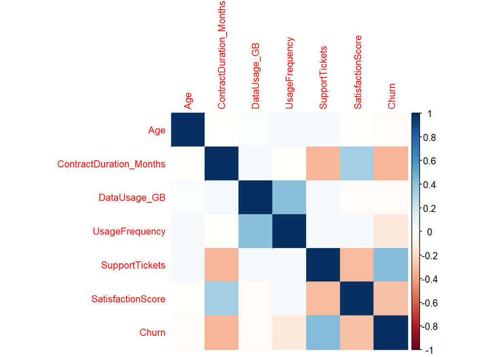

```r
corrplot(cor_matrix, method = "color", tl.cex = 0.8)
```

```r
#1.5
#Transforming the Skewed data : Log transformation
customer.data$SupportTickets <- log(customer.data$SupportTickets + 1 ) # we add the1 to avoid log(0)
customer.data$DataUsage_GB<- log(customer.data$DataUsage_GB +1 )

#Partitioning the data into Train-test split.
set.seed(42)
n <- nrow(customer.data)
p <- 0.7

training.indices <- sample(seq(1, n), size = n * p)
training.set <- customer.data[training.indices, ]
test.set <- customer.data[-training.indices, ]
```

One key ethical challenge in predicting customer churn is the risk of reinforcing socioeconomic bias. In South Africa’s diverse landscape, customers from rural or low-income communities may appear more likely to churn due to factors like lower usage or satisfaction, which could lead to their exclusion from retention efforts. This creates unfair outcomes and deepens inequality. To address this, ConnectZA should implement fairness-aware modelling by regularly checking for bias across demographic groups and ensuring that retention strategies include support for vulnerable customers. This approach promotes ethical, inclusive decision-making while still meeting business goals.

## TASK 2 - LINEAR PROBABILITY MODEL

```r
customer.data$SubscriptionTier <- as.factor(customer.data$SubscriptionTier)
summary(customer.data$SubscriptionTier)
```

```
##    Basic  Premium Standard
##      414      146      440
```

```r
my.lpm <- lm(Churn ~ ., data = training.set)
summary(my.lpm)
```

```
##
## Call:
## lm(formula = Churn ~ ., data = training.set)
##
## Residuals:
##      Min       1Q   Median       3Q      Max
## -0.51624 -0.19551 -0.08272  0.08217  1.00476
##
## Coefficients:
##                            Estimate Std. Error t value Pr(>|t|)
## (Intercept)               0.4072486  0.0861450   4.727 2.76e-06 ***
## Age                      -0.0005872  0.0009996  -0.587  0.55709
## SubscriptionTierPremium  -0.0857971  0.0607655  -1.412  0.15842
## SubscriptionTierStandard -0.0839462  0.0311520  -2.695  0.00722 **
## ContractDuration_Months  -0.0076237  0.0012077  -6.313 4.90e-10 ***
## DataUsage_GB              0.0337373  0.0130107   2.593  0.00971 **
## UsageFrequency           -0.0073835  0.0037582  -1.965  0.04985 *
## SupportTickets            0.1758261  0.0220048   7.990 5.64e-15 ***
## SatisfactionScore        -0.0418966  0.0105277  -3.980 7.63e-05 ***
## ---
## Signif. codes:  0 '***' 0.001 '**' 0.01 '*' 0.05 '.' 0.1 ' ' 1
##
## Residual standard error: 0.3003 on 691 degrees of freedom
## Multiple R-squared:  0.2667, Adjusted R-squared:  0.2582
## F-statistic: 31.42 on 8 and 691 DF,  p-value: < 2.2e-16
```

```r
yhat <- predict(my.lpm, newdata = test.set)
y <- test.set$Churn

Prediction_outside <- sum(yhat < 0 | yhat > 1)
Prediction_outside
```

```
## [1] 73
```

```r
Prediction_outside_class <- ifelse(yhat > 0.5, 1, 0)
conf_matrix <- table(Actual = test.set$Churn, Predicted = Prediction_outside_class)
conf_matrix
```

```
##       Predicted
## Actual   0   1
##      0 264   1
##      1  33   2
```

```r
accuracy <- (conf_matrix[1,1] + conf_matrix[2,2]) / sum(conf_matrix)
sensitivity <- conf_matrix[1,1] / sum(conf_matrix[1,])
specificity <- conf_matrix[2,2] / sum(conf_matrix[2,])

accuracy
```

```
## [1] 0.8866667
```

```r
sensitivity
```

```
## [1] 0.9962264
```

```r
specificity
```

```
## [1] 0.05714286
```

SatisfactionScore: A coefficient of -0.0419 implies higher satisfaction decreases churn likelihood each 1-point increase in satisfaction score reduces churn probability by 4.2% .Improving customer satisfaction could significantly reduce churn. ConnectZA should focus on improving service quality and customer experience. ContractDuration_Months: A coefficient of -0.0076 tells us that an additional month to a customers contract reduces their churn probability by around 0.76%. Then it clear that longer contracts help keep customers. ConnectZA could introduces maybe loyalty bonuses to customers to encourage longer commitments from them. THE LIMITATIONS OF THE LPM The LPM can output values less than 0 or greater than 1, which are not valid probabilities. This leads to interpretation issues and can result in poor prioritization of customers at risk of churn. For example a predicted value of 1.65 isn’t interpretable, and it may incorrectly flag a customer as extremely high risk The variance of residuals is not constant in LPMs, and relationships may not be linear. This weakens the reliability of the estimated effects, making it harder for ConnectZA to make data-driven business decisions. This could lead to poor prioritization of retention resources. The company might focus too much on customers who aren’t actually at high risk while missing those who are, just because the model can’t capture complex relationships properly. Although the LPM is simple and interpretable, its mathematical limitations can reduce the accuracy and usefulness of predictions

## TASK 3 - LOGISTIC REGRESSION

```r
MLR <- glm(Churn ~ ., data = training.set, family = binomial)
summary(MLR)
```

```
##
## Call:
## glm(formula = Churn ~ ., family = binomial, data = training.set)
##
## Coefficients:
##                          Estimate Std. Error z value Pr(>|z|)
## (Intercept)               1.69557    1.25328   1.353  0.17609
## Age                      -0.01504    0.01248  -1.205  0.22806
## SubscriptionTierPremium  -1.03633    0.73286  -1.414  0.15733
## SubscriptionTierStandard -1.04455    0.38768  -2.694  0.00705 **
## ContractDuration_Months  -0.13084    0.02251  -5.812 6.18e-09 ***
## DataUsage_GB              0.43349    0.17265   2.511  0.01205 *
## UsageFrequency           -0.11151    0.05009  -2.226  0.02600 *
## SupportTickets            1.93463    0.34690   5.577 2.45e-08 ***
## SatisfactionScore        -0.58713    0.14500  -4.049 5.14e-05 ***
## ---
## Signif. codes:  0 '***' 0.001 '**' 0.01 '*' 0.05 '.' 0.1 ' ' 1
##
## (Dispersion parameter for binomial family taken to be 1)
##
##     Null deviance: 570.57  on 699  degrees of freedom
## Residual deviance: 339.30  on 691  degrees of freedom
## AIC: 357.3
##
## Number of Fisher Scoring iterations: 7
```

The above logistic regression model gives a better fit than the Linear Probability Model and avoids invalid predictions since it all the predicted values from this model will fall within the valid probability range [0,1]. which makes its appropriate for real world business decision. The areas in which the model highlights that Customer satisfaction (SatistfactionScore), Contract Duration (ContractDuration_Months) and, Support Experience are areas that ConnectZA should focus on to reduce Churn.

```r
odds.ratios <- exp(coef(MLR))
odds.table <- data.frame(OddsRatio = odds.ratios)
odds.table
```

```
##                          OddsRatio
## (Intercept)              5.4497243
## Age                      0.9850726
## SubscriptionTierPremium  0.3547544
## SubscriptionTierStandard 0.3518499
## ContractDuration_Months  0.8773553
## DataUsage_GB             1.5426318
## UsageFrequency           0.8944830
## SupportTickets           6.9214821
## SatisfactionScore        0.5559205
```

```r
#3.3
yhat.predicted <- predict(MLR, newdata = test.set, type = "response")
yhat.pred.class <- ifelse(yhat.predicted > 0.5, 1, 0)

conf_matrix_mrl <- table(Actual = test.set$Churn, Predicted = yhat.pred.class)
conf_matrix_mrl
```

```
##       Predicted
## Actual   0   1
##      0 256   9
##      1  23  12
```

```r
accuracy <- (conf_matrix_mrl[1,1] + conf_matrix_mrl[2,2]) / sum(conf_matrix_mrl)
sensitivity <- conf_matrix_mrl[1,1] / sum(conf_matrix_mrl[1,])
specificity <- conf_matrix_mrl[2,2] / sum(conf_matrix_mrl[2,])

accuracy
```

```
## [1] 0.8933333
```

```r
sensitivity
```

```
## [1] 0.9660377
```

```r
specificity
```

```
## [1] 0.3428571
```